# Steps Used

#### 5 Since this is regression model determined that I could either use Linear Regression or Random Forest algorithms.

## From the plot of KPT time and total Amount I deduced that there is no linear relationship between these 2 and thus I inferred that Random Forest algorithm is more appropriate for this dataset.

## Features I initially selected for prediction modeling are;

#### 1. Pickupid

#### 2. total_amount

#### 3. intofweek

## Split the curated data set into Training set and Test set in 70% and 30% ratio respectively.

### Model used is RandomForest Classifier with estimator(decision tree)

# RESULT (Result 3) Go to result 3 below

#### The following were the features used to arrive at 76% accuracy. THIS WAS THE FIRST RUN ON DATASET.

#### 1. Pickupid

#### 2. total_amount

#### 3. intofweek

### To improve the accuracy further with Random Forest I increased the decision trees to 500 and to reduce the modeling time I decreased the datapoints to 1lakh, I arrived at an accuracy of 80%. I also decided to include another feature (time zone).

#### 1. Pickupid

#### 2. total_amount

#### 3. intofweek

#### 4. Time zone

## On the 3rd modeling run, I reduced the decision tress to 120 and used all the data points resulting in an accuracy of 82%. Reason for reducing the decision trees is a limitations of my PCs hardware.

### Features used

#### 1. Pickupid

#### 2. total_amount

#### 3. intofweek

#### 4. Time zone

## Challenges faced

##### Severly :- My machine kernel is dead several time as data point are too many

##### Processing time is around 10 -15 minute for 4.8 lakh point need to wait for results some time kernel is dead so need to start from beginning

##### Accuracy of Algorithm can be easily increased if Machine is more powerful as i am unable to use more decision tree

## Prediction Accuracy

#### Accuracy could further be improved by using a more powerful machine as that would make it easier to use more decision trees in Random Forest Algorithm. I've used 120 Decision Trees and if this number was any larger the accuracy would be correspondingly higher.

#### If I had 60 to 80% availability to Number of items per order and cost of two items (In the given dataset very few records had these values) and this limited the model's accuracy. Because the preparation time is directly proportional to number of items and if each item was ordered more than once. (Prep time for same item regardless of quantity usually remains the same)

#### During the data selection process, I could have used k fold with Random forest to increase the accuracy of the model.

### I wanted to use Naive Bayes algorithm to predict KPT and compare both algorithms but due to my machine's limitations I was forced to use only Random Forest algorithm. Each prediction model was taking more than 20 minutes to fit the model and 10 to 15 minutes to generate prediction results.

### Final result you can check at end of notebook

### Importing dataset using pandas

```python
import pandas as pd
import os
os.getcwd()
os.chdir('/Users/soni/Documents/Data_z')

# Loading Dataset as data
data=pd.read_csv('test_data.csv',encoding='utf-8')
```

#### Description of Data

```python
# Description of data
data.describe()
```

|  | id | pickup_user_id | total_amount | pickup_user_address_id | cost_for_two |
| --- | --- | --- | --- | --- | --- |
| count | 4.841920e+05 | 4.841920e+05 | 484192.000000 | 4.841920e+05 | 111715.000000 |
| mean | 2.355218e+07 | 1.143798e+07 | 578.257936 | 1.703596e+07 | 599.003760 |
| std | 2.343470e+05 | 1.581639e+05 | 615.429059 | 2.099367e+05 | 311.661838 |
| min | 2.243799e+07 | 9.678620e+06 | 30.000000 | 1.461220e+07 | 100.000000 |
| 25% | 2.340605e+07 | 1.133091e+07 | 259.390000 | 1.688741e+07 | 400.000000 |
| 50% | 2.360755e+07 | 1.145768e+07 | 405.800000 | 1.704667e+07 | 500.000000 |
| 75% | 2.373984e+07 | 1.153506e+07 | 678.500000 | 1.715065e+07 | 800.000000 |
| max | 2.384750e+07 | 1.176280e+07 | 29070.480000 | 1.742382e+07 | 5000.000000 |

### Function definition to calculate time -difference in minute

##### This function return time in minutes

```python
import time
def time_diff(x1,x2):

    pattern= '%d/%m/%y %H:%M'
    time1 = int(time.mktime(time.strptime(x1, pattern)))
    time2 = int(time.mktime(time.strptime(x2, pattern)))

    return ((time2-time1)/60) # return time in minutes
```

### Function definition to calculate day of the week

##### Whether the day of week is Monday , Tuesday or wednesday......

```python
import datetime

def day_of_week(x):
    d=datetime.datetime.strptime(x[:8],'%d/%m/%y').strftime('%y,%m,%d')
    year,month,dt = int(d[:2]),int(d[3:5]),int(d[6:])
    dayofweek = datetime.date(year,month,dt).strftime("%A")
    return dayofweek
```

### Removing rows which does not contain shipped time

#### and we will see the difference in actual data and df is not much

```python
df = data[pd.notnull(data['shipped_at'])]
```

#### as we compare the lenght of two you get the result as only 290 rows are deleted from

```python
print("Lenght of raw data {}".format(len(data)))
print("Length of data after removing null point {}".format(len(df)))
print("No of data point removed {}".format(len(data)-len(df)))
```

```
Lenght of raw data 484192
Length of data after removing null point 483902
No of data point removed 290
```

```python
len(data)
```

```
484192
```

### Kitchen Preparation time is = shipped_at - linked_at

### Converting dataframe to list

```python
shipped_at = list(df['shipped_at'])

linked_at = list(df['linked_at'])
```

```python
len(data[pd.notnull(data['shipped_at'])])
```

```
483902
```

```python
# Calculating difference between order linked to resturant and order shipped from resturant as KPT

KPT =[]
for i in range(len(shipped_at)):

    t=time_diff(linked_at[i],shipped_at[i])
    KPT.append(t)
```

### Adding new dataframe columns KPT

```python
df['KPT']=KPT
```

```python
df.columns
```

```
Index(['id', 'pickup_user_id', 'total_amount', 'pickup_user_address_id',
       'created_at.x', 'ki', 'cost_for_two', 'created_at.y',
       'driver_assigned_at', 'reached_shop_at', 'shipped_at',
       'reached_customer_at', 'complete_at', 'linked_at', 'item_name', 'KPT'],
      dtype='object')
```

### adding day of week in order to know if there is large order in Weekdays or Weekends

```python
day =[]
for i in range(len(linked_at)):
    day.append(day_of_week(linked_at[i]))
```

```python
day
```

[output not shown]

[output cut: 946 more lines]

```
 'Friday',
 'Friday',
 'Friday',
 'Friday',
 'Friday',
 'Friday',
 'Friday',
 'Friday',
 'Friday',
 'Friday',
 'Friday',
 'Friday',
 'Friday',
 'Friday',
 ...]
```

```python
df['dayofweek'] = day
```

#### Adding new column day of week

```python
df.columns
```

```
Index(['id', 'pickup_user_id', 'total_amount', 'pickup_user_address_id',
       'created_at.x', 'ki', 'cost_for_two', 'created_at.y',
       'driver_assigned_at', 'reached_shop_at', 'shipped_at',
       'reached_customer_at', 'complete_at', 'linked_at', 'item_name', 'KPT',
       'dayofweek'],
      dtype='object')
```

```python
df.head()
```

|  | id | pickup_user_id | total_amount | pickup_user_address_id | created_at.x | ki | cost_for_two | created_at.y | driver_assigned_at | reached_shop_at | shipped_at | reached_customer_at | complete_at | linked_at | item_name | KPT | dayofweek |
| --- | --- | --- | --- | --- | --- | --- | --- | --- | --- | --- | --- | --- | --- | --- | --- | --- | --- |
| 0 | 22437988 | 10345796 | 961.7 | 15530971 | NaN | NaN | NaN | 01/08/17 11:20 | 01/08/17 11:26 | 01/08/17 11:30 | 01/08/17 11:31 | 01/08/17 12:11 | 01/08/17 12:12 | 01/08/17 11:26 | NaN | 5.0 | Tuesday |
| 1 | 22437990 | 10670850 | 330.0 | 15982357 | NaN | NaN | NaN | 01/08/17 11:21 | 01/08/17 11:22 | 01/08/17 11:44 | 01/08/17 11:45 | 01/08/17 11:55 | 01/08/17 11:56 | 01/08/17 11:22 | NaN | 23.0 | Tuesday |
| 2 | 22438023 | 10348502 | 299.6 | 15534234 | NaN | NaN | NaN | 01/08/17 11:30 | 01/08/17 11:30 | 01/08/17 11:48 | 01/08/17 11:50 | 01/08/17 12:00 | 01/08/17 12:00 | 01/08/17 11:30 | NaN | 20.0 | Tuesday |
| 3 | 22438033 | 10889894 | 1965.2 | 16276686 | NaN | NaN | NaN | 01/08/17 11:33 | 01/08/17 11:57 | 01/08/17 11:59 | 01/08/17 12:49 | 01/08/17 13:27 | 01/08/17 13:27 | 01/08/17 11:57 | NaN | 52.0 | Tuesday |
| 4 | 22438037 | 10006319 | 314.0 | 15054245 | NaN | NaN | NaN | 01/08/17 11:35 | 01/08/17 11:35 | 01/08/17 11:48 | 01/08/17 11:57 | 01/08/17 12:18 | 01/08/17 12:18 | 01/08/17 11:35 | NaN | 22.0 | Tuesday |

#### Calculating no of resturant using pickup order id data

##### as number of resturant is limited so they are unique and also depend on the frequency with which order is placed on a specific resturant need to know is necessary

```python
print("No of resturant is {} from  these-->{} many restaurant id ".format(len(set(list(df['pickup_user_id']))),len(df)))
```

```
No of resturant is 2846 from  these-->483902 many restaurant id
```

### Making box plot of KPT to understand average kpt time of the data

```python
import matplotlib.pyplot as plt
```

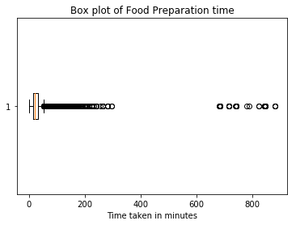

```python
plt.boxplot(KPT,vert=False)
plt.xlabel("Time taken in minutes")
plt.title("Box plot of Food Preparation time")

plt.show()
```

### As we can see that from Above Box plot there is outlier where food prepartion time is beyond 100minute need to be cancelled as end user can't wait for 100 minute for his food to be served

```python
df['KPT'].describe()
```

```
count    483902.000000
mean         25.266283
std          15.595960
min           0.000000
25%          16.000000
50%          22.000000
75%          31.000000
max         881.000000
Name: KPT, dtype: float64
```

```python
df.columns
```

```
Index(['id', 'pickup_user_id', 'total_amount', 'pickup_user_address_id',
       'created_at.x', 'ki', 'cost_for_two', 'created_at.y',
       'driver_assigned_at', 'reached_shop_at', 'shipped_at',
       'reached_customer_at', 'complete_at', 'linked_at', 'item_name', 'KPT',
       'dayofweek'],
      dtype='object')
```

```python
df[['total_amount']][df['KPT']>100].describe()
```

|  | total_amount |
| --- | --- |
| count | 1131.000000 |
| mean | 1283.668683 |
| std | 3841.043451 |
| min | 100.800000 |
| 25% | 317.820000 |
| 50% | 480.000000 |
| 75% | 811.160000 |
| max | 29070.480000 |

#### As we can see from data that 1131 count are our outliers

```python
# no of rows which are taking less than 100 minute to prepare order
len(df[df['KPT']<100]) # Now we are left with this much rows
```

```
482733
```

```python
df = df[df['KPT']<100]
df
```

[output not shown]

```python
#converting Monday Tuesday and Wednesday as 1 , 2, 3
intofweek =[]
d ={'Sunday':0,'Monday':1,'Tuesday':2,'Wednesday':3,'Thursday':4,'Friday':5,'Saturday':6}
day=list(df['dayofweek'])
for i in day:
    if i in d:
        intofweek.append(d[i])
```

```python
df['int_of_week'] = intofweek
```

#### No of columns

```python
df.columns
```

```
Index(['id', 'pickup_user_id', 'total_amount', 'pickup_user_address_id',
       'created_at.x', 'ki', 'cost_for_two', 'created_at.y',
       'driver_assigned_at', 'reached_shop_at', 'shipped_at',
       'reached_customer_at', 'complete_at', 'linked_at', 'item_name', 'KPT',
       'dayofweek', 'int_of_week'],
      dtype='object')
```

#### Now we will plot scatter plot to see if which algorithm we can apply on this dataset

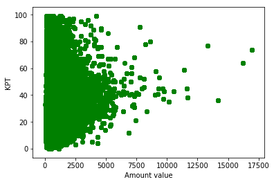

```python
import matplotlib.pyplot as plt
plt.scatter(df['total_amount'], df['KPT'], color='green')
plt.xlabel('Amount value')
plt.ylabel('KPT')
plt.show()
```

### As you can see from above scatter plot that it KPT doesn't vary lineary with amount so we can't use linear regression

### Let's us use Random forest Algorithm and know the accuracy of our prediction model

```python
import pandas as pd
from sklearn import datasets
from sklearn.model_selection import train_test_split
from matplotlib import pyplot as plt
```

```python
from sklearn.model_selection import train_test_split
```

```python
df[['pickup_user_id', 'total_amount', 'int_of_week']][0:100001]
```

|  | pickup_user_id | total_amount | int_of_week |
| --- | --- | --- | --- |
| 0 | 10345796 | 961.70 | 2 |
| 1 | 10670850 | 330.00 | 2 |
| 2 | 10348502 | 299.60 | 2 |
| 3 | 10889894 | 1965.20 | 2 |
| 4 | 10006319 | 314.00 | 2 |
| 5 | 10970635 | 360.00 | 2 |
| 6 | 9678620 | 326.57 | 2 |
| 7 | 11063639 | 260.00 | 2 |
| 8 | 10352974 | 637.11 | 2 |
| 9 | 10889894 | 1239.50 | 2 |
| 10 | 10345796 | 259.60 | 2 |
| 11 | 10831638 | 852.40 | 2 |
| 12 | 10355981 | 663.65 | 2 |
| 13 | 10355981 | 663.65 | 2 |
| 14 | 10355981 | 663.65 | 2 |
| 15 | 10350088 | 540.96 | 2 |
| 16 | 11047122 | 237.07 | 2 |
| 17 | 10047828 | 407.10 | 2 |
| 18 | 10831638 | 309.60 | 2 |
| 19 | 10418079 | 244.20 | 2 |
| 20 | 10418079 | 244.20 | 2 |
| 21 | 10346980 | 146.82 | 2 |
| 22 | 10120087 | 288.72 | 2 |
| 23 | 10345796 | 153.40 | 2 |
| 24 | 10345796 | 171.10 | 2 |
| 25 | 10388154 | 396.32 | 2 |
| 26 | 11066682 | 130.00 | 2 |
| 27 | 10915362 | 232.40 | 2 |
| 28 | 10350088 | 241.08 | 2 |
| 29 | 10584171 | 289.00 | 2 |
| ... | ... | ... | ... |
| 100418 | 11256991 | 325.00 | 0 |
| 100419 | 11419680 | 531.50 | 0 |
| 100420 | 11419680 | 531.50 | 0 |
| 100421 | 11419680 | 531.50 | 0 |
| 100422 | 11419680 | 531.50 | 0 |
| 100423 | 11271854 | 304.55 | 0 |
| 100424 | 11271854 | 304.55 | 0 |
| 100425 | 11271854 | 304.55 | 0 |
| 100426 | 11271854 | 304.55 | 0 |
| 100427 | 11269356 | 422.25 | 0 |
| 100428 | 11269356 | 422.25 | 0 |
| 100429 | 11269356 | 422.25 | 0 |
| 100430 | 11269356 | 422.25 | 0 |
| 100431 | 11331331 | 232.50 | 0 |
| 100432 | 11331331 | 232.50 | 0 |
| 100433 | 11502197 | 336.80 | 0 |
| 100434 | 11463247 | 346.80 | 0 |
| 100435 | 11463247 | 346.80 | 0 |
| 100436 | 11463247 | 346.80 | 0 |
| 100437 | 11451009 | 140.00 | 0 |
| 100438 | 11124956 | 470.70 | 0 |
| 100439 | 11124956 | 470.70 | 0 |
| 100440 | 11406625 | 460.00 | 0 |
| 100441 | 11452269 | 201.60 | 0 |
| 100442 | 11452269 | 201.60 | 0 |
| 100443 | 11256991 | 325.00 | 0 |
| 100444 | 11452456 | 166.08 | 0 |
| 100445 | 11452456 | 166.08 | 0 |
| 100446 | 11420783 | 436.60 | 0 |
| 100447 | 11420783 | 436.60 | 0 |

100001 rows × 3 columns

#### Here i have use three feature as pickup order id , total amount and int of week mean sat sund monday

#### split data set into 70 to 30 ratio

```python
X=df[['pickup_user_id', 'total_amount', 'int_of_week']]  # Features
y=df['KPT']  # Labels

# Split dataset into training set and test set
X_train, X_test, y_train, y_test = train_test_split(X, y, test_size=0.3) # 70% training and 30% test
```

```python
#load our model
from sklearn.ensemble import RandomForestClassifier
model = RandomForestClassifier(n_estimators=100,random_state=42)
```

```python
#thit is how we get the feature importance with simple steps:
model.fit(X_train,y_train)
# display the relative importance of each attribute
importances = model.feature_importances_
#Sort it
print ("Sorted Feature Importance:")
sorted_feature_importance = sorted(zip(importances, list(X_train)), reverse=True)
print (sorted_feature_importance)
```

```
Sorted Feature Importance:
[(0.5705229539899211, 'total_amount'), (0.4166714094790386, 'pickup_user_id'), (0.012805636531040358, 'int_of_week')]
```

```python
import numpy as np

# Use the forest's predict method on the test data
predictions = model.predict(X_test)

# Calculate the absolute errors
errors = abs(predictions - y_test)

errors
```

```
266974    32.0
428856     0.0
428277     0.0
371854     0.0
470168    11.0
34798      0.0
369644     0.0
309870    36.0
349582     0.0
451687     0.0
136078     0.0
117579     0.0
187792     0.0
175952     0.0
30118     22.0
```

[output cut: 47 more lines]

```python
# Print out the mean absolute error (mae)
print('Mean Absolute Error:', round(np.mean(errors), 2), 'degrees.')
```

```
Mean Absolute Error: 4.32 degrees.
```

```python
# Calculate mean absolute percentage error (MAPE)
mape = 100 * (errors / y_test)

# Calculate and display accuracy
accuracy = 100 - np.mean(mape)
print('Accuracy:', round(accuracy, 2), '%.')
```

```
Accuracy: 75.95 %.
```

```python
pred=list(predictions)
```

```python
y_t=list(y_test)
```

```python
model_df = pd.DataFrame(y_t,columns=['Y_test'])
```

```python
model_df['Predictions']=pd.DataFrame(predictions)
```

```python
model_df
```

|  | Y_test | Predictions |
| --- | --- | --- |
| 0 | 6.0 | 38.0 |
| 1 | 33.0 | 33.0 |
| 2 | 18.0 | 18.0 |
| 3 | 34.0 | 34.0 |
| 4 | 25.0 | 36.0 |
| 5 | 8.0 | 8.0 |
| 6 | 9.0 | 9.0 |
| 7 | 56.0 | 20.0 |
| 8 | 30.0 | 30.0 |
| 9 | 10.0 | 10.0 |
| 10 | 11.0 | 11.0 |
| 11 | 16.0 | 16.0 |
| 12 | 20.0 | 20.0 |
| 13 | 16.0 | 16.0 |
| 14 | 16.0 | 38.0 |
| 15 | 14.0 | 15.0 |
| 16 | 10.0 | 21.0 |
| 17 | 19.0 | 60.0 |
| 18 | 25.0 | 23.0 |
| 19 | 24.0 | 20.0 |
| 20 | 19.0 | 26.0 |
| 21 | 6.0 | 19.0 |
| 22 | 18.0 | 13.0 |
| 23 | 39.0 | 17.0 |
| 24 | 52.0 | 52.0 |
| 25 | 39.0 | 14.0 |
| 26 | 47.0 | 47.0 |
| 27 | 12.0 | 18.0 |
| 28 | 12.0 | 12.0 |
| 29 | 15.0 | 15.0 |
| ... | ... | ... |
| 144790 | 42.0 | 42.0 |
| 144791 | 72.0 | 72.0 |
| 144792 | 38.0 | 29.0 |
| 144793 | 17.0 | 10.0 |
| 144794 | 24.0 | 24.0 |
| 144795 | 26.0 | 20.0 |
| 144796 | 29.0 | 12.0 |
| 144797 | 14.0 | 14.0 |
| 144798 | 59.0 | 59.0 |
| 144799 | 23.0 | 23.0 |
| 144800 | 8.0 | 8.0 |
| 144801 | 24.0 | 24.0 |
| 144802 | 24.0 | 18.0 |
| 144803 | 21.0 | 14.0 |
| 144804 | 42.0 | 23.0 |
| 144805 | 46.0 | 46.0 |
| 144806 | 26.0 | 26.0 |
| 144807 | 55.0 | 55.0 |
| 144808 | 24.0 | 21.0 |
| 144809 | 13.0 | 13.0 |
| 144810 | 8.0 | 8.0 |
| 144811 | 14.0 | 14.0 |
| 144812 | 39.0 | 39.0 |
| 144813 | 15.0 | 15.0 |
| 144814 | 23.0 | 23.0 |
| 144815 | 40.0 | 40.0 |
| 144816 | 24.0 | 52.0 |
| 144817 | 5.0 | 6.0 |
| 144818 | 11.0 | 10.0 |
| 144819 | 11.0 | 11.0 |

144820 rows × 2 columns

```python
model_df['error']=pd.DataFrame(np.array(y_t)-np.array(pred))
```

```python
model_df
```

|  | Y_test | Predictions | error |
| --- | --- | --- | --- |
| 0 | 6.0 | 38.0 | -32.0 |
| 1 | 33.0 | 33.0 | 0.0 |
| 2 | 18.0 | 18.0 | 0.0 |
| 3 | 34.0 | 34.0 | 0.0 |
| 4 | 25.0 | 36.0 | -11.0 |
| 5 | 8.0 | 8.0 | 0.0 |
| 6 | 9.0 | 9.0 | 0.0 |
| 7 | 56.0 | 20.0 | 36.0 |
| 8 | 30.0 | 30.0 | 0.0 |
| 9 | 10.0 | 10.0 | 0.0 |
| 10 | 11.0 | 11.0 | 0.0 |
| 11 | 16.0 | 16.0 | 0.0 |
| 12 | 20.0 | 20.0 | 0.0 |
| 13 | 16.0 | 16.0 | 0.0 |
| 14 | 16.0 | 38.0 | -22.0 |
| 15 | 14.0 | 15.0 | -1.0 |
| 16 | 10.0 | 21.0 | -11.0 |
| 17 | 19.0 | 60.0 | -41.0 |
| 18 | 25.0 | 23.0 | 2.0 |
| 19 | 24.0 | 20.0 | 4.0 |
| 20 | 19.0 | 26.0 | -7.0 |
| 21 | 6.0 | 19.0 | -13.0 |
| 22 | 18.0 | 13.0 | 5.0 |
| 23 | 39.0 | 17.0 | 22.0 |
| 24 | 52.0 | 52.0 | 0.0 |
| 25 | 39.0 | 14.0 | 25.0 |
| 26 | 47.0 | 47.0 | 0.0 |
| 27 | 12.0 | 18.0 | -6.0 |
| 28 | 12.0 | 12.0 | 0.0 |
| 29 | 15.0 | 15.0 | 0.0 |
| ... | ... | ... | ... |
| 144790 | 42.0 | 42.0 | 0.0 |
| 144791 | 72.0 | 72.0 | 0.0 |
| 144792 | 38.0 | 29.0 | 9.0 |
| 144793 | 17.0 | 10.0 | 7.0 |
| 144794 | 24.0 | 24.0 | 0.0 |
| 144795 | 26.0 | 20.0 | 6.0 |
| 144796 | 29.0 | 12.0 | 17.0 |
| 144797 | 14.0 | 14.0 | 0.0 |
| 144798 | 59.0 | 59.0 | 0.0 |
| 144799 | 23.0 | 23.0 | 0.0 |
| 144800 | 8.0 | 8.0 | 0.0 |
| 144801 | 24.0 | 24.0 | 0.0 |
| 144802 | 24.0 | 18.0 | 6.0 |
| 144803 | 21.0 | 14.0 | 7.0 |
| 144804 | 42.0 | 23.0 | 19.0 |
| 144805 | 46.0 | 46.0 | 0.0 |
| 144806 | 26.0 | 26.0 | 0.0 |
| 144807 | 55.0 | 55.0 | 0.0 |
| 144808 | 24.0 | 21.0 | 3.0 |
| 144809 | 13.0 | 13.0 | 0.0 |
| 144810 | 8.0 | 8.0 | 0.0 |
| 144811 | 14.0 | 14.0 | 0.0 |
| 144812 | 39.0 | 39.0 | 0.0 |
| 144813 | 15.0 | 15.0 | 0.0 |
| 144814 | 23.0 | 23.0 | 0.0 |
| 144815 | 40.0 | 40.0 | 0.0 |
| 144816 | 24.0 | 52.0 | -28.0 |
| 144817 | 5.0 | 6.0 | -1.0 |
| 144818 | 11.0 | 10.0 | 1.0 |
| 144819 | 11.0 | 11.0 | 0.0 |

144820 rows × 3 columns

```python
# Import the model we are using
from sklearn.ensemble import RandomForestRegressor

# Instantiate model with 1000 decision trees
rf = RandomForestRegressor(n_estimators = 1000, random_state = 42)

# Train the model on training data
rf.fit(train_features, train_labels);
```

[output not shown]

```python
from sklearn.ensemble import RandomForestRegressor
rf = RandomForestRegressor(n_estimators = 500, random_state = 42)
#thit is how we get the feature importance with simple steps:
rf.fit(X_train,y_train)
# display the relative importance of each attribute
importances = model.feature_importances_
#Sort it
print ("Sorted Feature Importance:")
sorted_feature_importance = sorted(zip(importances, list(X_train)), reverse=True)
print (sorted_feature_importance)
```

[output not shown]

```python
linked_at = list(df['linked_at'])
time_zone =[]

# creating 24 time zone to know it affect the KPT tiem

for index,val in enumerate (linked_at):
    time_zone.append((val[9:11]))
```

```python
linked_at[1000][9:11]
```

```
'9:'
```

```python
linked_at[0]
```

```
'01/08/17 11:26'
```

```python
df['Time zone']=time_zone
```

```python
#len(df)
len(time_zone)
```

```
482733
```

```python
t_z =[]
for index,val in enumerate(time_zone):

    if ":" in val:
        t_z.append(int(val[0]))
        #print(index,int(val[0:1]))
    else:
        t_z.append(int(val[0:2]))
        #print(index,int(val))
```

```python
len(t_z)
```

```
482733
```

```python
linked_at[1000]
```

```
'05/08/17 9:04'
```

```python
df['Time Zone']=t_z
```

```python
del df['Time zone']
```

```python
df.columns
```

```
Index(['id', 'pickup_user_id', 'total_amount', 'pickup_user_address_id',
       'created_at.x', 'ki', 'cost_for_two', 'created_at.y',
       'driver_assigned_at', 'reached_shop_at', 'shipped_at',
       'reached_customer_at', 'complete_at', 'linked_at', 'item_name', 'KPT',
       'dayofweek', 'int_of_week', 'Time Zone'],
      dtype='object')
```

#### For 1lakh data point i am getting an accuracy of ~80% in KPT time using 500 estimators

```python
X=df[['pickup_user_id', 'total_amount', 'int_of_week','Time Zone']] [0:100001] # Features
y=df['KPT'][0:100001]  # Labels

# Split dataset into training set and test set
X_train, X_test, y_train, y_test = train_test_split(X, y, test_size=0.3) # 70% training and 30% test

#load our model
from sklearn.ensemble import RandomForestClassifier
model = RandomForestClassifier(n_estimators=500,random_state=42)

#thit is how we get the feature importance with simple steps:
model.fit(X_train,y_train)
# display the relative importance of each attribute
importances = model.feature_importances_
#Sort it
print ("Sorted Feature Importance:")
sorted_feature_importance = sorted(zip(importances, list(X_train)), reverse=True)
print (sorted_feature_importance)
```

```
Sorted Feature Importance:
[(0.41755044446918016, 'total_amount'), (0.30158694509474543, 'pickup_user_id'), (0.15499798725009903, 'Time Zone'), (0.1258646231859755, 'int_of_week')]
```

```python
import numpy as np

# Use the forest's predict method on the test data
predictions = model.predict(X_test)

# Calculate the absolute errors
errors = abs(predictions - y_test)

# Print out the mean absolute error (mae)
print('Mean Absolute Error:', round(np.mean(errors), 2), 'degrees.')

# Calculate mean absolute percentage error (MAPE)
mape = 100 * (errors / y_test)

# Calculate and display accuracy
accuracy = 100 - np.mean(mape)
print('Accuracy:', round(accuracy, 2), '%.')
```

```
Mean Absolute Error: 3.67 degrees.
Accuracy: 79.57 %.
```

```python
import matplotlib.pyplot as plt
```

#### A plot to show the Predicted value and actual value of KPT time for 1lakh data point with 30000 test case

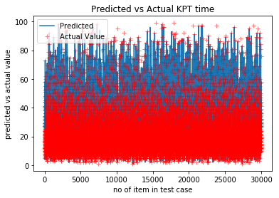

```python
x = range(len(predictions))
y1 = list(predictions)
plt.plot(x, y1, label = "Predicted")
y2 = list(y_test)
# plotting the line 2 points
plt.plot(x, y2,'r+', label = "Actual Value",alpha=0.5)
plt.xlabel('no of item in test case')
# Set the y axis label of the current axis.
plt.ylabel('predicted vs actual value')
# Set a title of the current axes.
plt.title('Predicted vs Actual KPT time')
# show a legend on the plot
plt.legend()
# Display a figure.
plt.show()
```

### Now checking with all available data point(~4.8lakh) using 120 decision tree,

# I am getting an accuracy of ~82%

```python
X=df[['pickup_user_id', 'total_amount', 'int_of_week','Time Zone']] # Features
y=df['KPT']  # Labels

# Split dataset into training set and test set
X_train, X_test, y_train, y_test = train_test_split(X, y, test_size=0.3) # 70% training and 30% test

#load our model
from sklearn.ensemble import RandomForestClassifier
model = RandomForestClassifier(n_estimators=120,random_state=42)

#thit is how we get the feature importance with simple steps:
model.fit(X_train,y_train)
# display the relative importance of each attribute
importances = model.feature_importances_
#Sort it
print ("Sorted Feature Importance:")
sorted_feature_importance = sorted(zip(importances, list(X_train)), reverse=True)
print (sorted_feature_importance)
```

```
Sorted Feature Importance:
[(0.41341385373676537, 'total_amount'), (0.3389624860660007, 'pickup_user_id'), (0.1320129528954144, 'Time Zone'), (0.11561070730181955, 'int_of_week')]
```

```python
import numpy as np

# Use the forest's predict method on the test data
predictions = model.predict(X_test)

# Calculate the absolute errors
errors = abs(predictions - y_test)

# Print out the mean absolute error (mae)
print('Mean Absolute Error:', round(np.mean(errors), 2), 'degrees.')

# Calculate mean absolute percentage error (MAPE)
mape = 100 * (errors / y_test)

# Calculate and display accuracy
accuracy = 100 - np.mean(mape)
print('Accuracy:', round(accuracy, 2), '%.')
```

```
Mean Absolute Error: 3.21 degrees.
Accuracy: 81.73 %.
```

```python
model_rf = pd.DataFrame(list(y_test),columns=['Y_test'])
```

```python
model_rf['Predicted'] = list(predictions)
```

```python
model_rf['errors'] = pd.DataFrame(abs(np.array(y_test)-np.array(predictions)))
```